# Indicadores de informalidad en el Perú en el período 2011 – 2022

2023-01-29

## I. Objetivo

Se busca realizar un análisis descriptivo del sector informal en el mercado laboral peruano y comparar las variaciones a lo largo de los años 2011 al 2022 poniendo énfasis en los años de la pandemia del COVID-19. Para este fin, se utilizará el software estadístico R, en específico, el paquete gráfico *“ggplot2”* y el paquete de manejo de bases de datos *“tidyverse”*.

Adicionalmente, se realizará un análisis comparativo entre los 24 departamentos del Perú y la Provincia Constitucional del Callao, para lo cual se utilizarán los paquetes *“sf”*, *“purrr”*, *“ggrepel”* y *“gganimate”* a fin de manipular datos espaciales y presentar mapas con las tasas de informalidad.

## II. Metodología

## a. Base de Datos

Para la elaboración de la base de datos se utilizaron los datos de:

- Estadísticas de empleo de la página web del [INEI (2023)](https://www.inei.gob.pe/estadisticas/indice-tematico/ocupacion-y-vivienda/) para los años 2011 al 2021.
- La Encuesta Nacional de Hogares [(ENAHO)](https://iinei.inei.gob.pe/microdatos/) para el 2022.
- Información geoespacial de los 24 departamentos del Perú y la Provincia Constitucional del Callao obtenido de [GEOGPS (2015)](https://www.geogpsperu.com/2014/03/base-de-datos-peru-shapefile-shp-minam.html).

Así, se cuentan con 12 observaciones y con 94 variables en total. De esta manera, se estructuró la base de datos con las siguientes variables:

- Base principal, compuesta por:
  - Tasa de informalidad
  - Tasa de informalidad por zonas (rural-urbano)
  - Tasa de informalidad en sexo (hombres-mujeres)
  - Población ocupada total e informal por grupo etáreo
  - Población ocupada total e informal por tamaño de empresa
  - Ingresos promedio mensuales
  - Ingresos promedio mensuales de trabajadores formales
  - Ingresos promedio mensuales de trabajadores informales
- Población Economicamente Activa (PEA) ocupada
- PEA total (ocupada y desocupada)
- PEA ocupada urbana y rural
- PEA ocupada hombres y mujeres
- Tasa de informalidad y población total ocupada de los 24 departamentos del Perú y la Provincia Constitucional del Callao.
- Datos geoespaciales por límite departamental.

## b. Preprocesamiento

De los datos se observa que es conveniente contar con algunas variables relevantes adicionales que permitan mejoras en el análisis y compresión de los datos. De esta manera, a partir de los datos establecidos, se construyen variables como:

- PEA ocupada femenina
- PEA desocupada
- PEA ocupada rural
- Tasa de informalidad por rango de edades (cuatro variables adicionales)
- Tasa de informalidad por tamaño de empresa (tres variables adicionales)
- Tasa de desempleo

## Descripción de la informalidad

```
## Base$tasa_inf
##        n  missing distinct     Info     Mean      Gmd      .05      .10
##       12        0       12        1    73.73    1.647    72.23    72.45
##      .25      .50      .75      .90      .95
##    72.69    73.45    74.50    75.32    76.02
##
## lowest : 71.97162 72.43837 72.54650 72.74092 72.83699
## highest: 73.76779 74.31488 75.06388 75.34852 76.84696
##
## Value      71.97162 72.43837 72.54650 72.74092 72.83699 73.15043 73.74371
## Frequency         1        1        1        1        1        1        1
## Proportion    0.083    0.083    0.083    0.083    0.083    0.083    0.083
##
## Value      73.76779 74.31488 75.06388 75.34852 76.84696
## Frequency         1        1        1        1        1
## Proportion    0.083    0.083    0.083    0.083    0.083
```

## Estadísticas descriptivas

```
##     PEA_ocu         Tasa_desempleo  Ing_prom_men_f Ing_prom_men_i
##  Min.   :14901782   Min.   :3.510   Min.   :1369   Min.   :528.0
##  1st Qu.:15647826   1st Qu.:3.863   1st Qu.:1694   1st Qu.:619.1
##  Median :16058178   Median :3.982   Median :1911   Median :682.6
##  Mean   :16227648   Mean   :4.498   Mean   :1841   Mean   :663.0
##  3rd Qu.:16862398   3rd Qu.:4.553   3rd Qu.:1973   3rd Qu.:708.1
##  Max.   :17843094   Max.   :7.413   Max.   :2234   Max.   :795.9
```

## Valores perdidos

Valores perdidos en la base principal y de regiones

```
## [1] FALSE
```

```
## [1] TRUE
```

```
## # A tibble: 6 × 3
##   variable           n_miss pct_miss
##   <chr>               <int>    <dbl>
## 1 LIMA_METROPOLITANA      1     8.33
## 2 LIMA_PROVINCIAS         1     8.33
## 3 AMAZONAS                0     0
## 4 ANCASH                  0     0
## 5 APURIMAC                0     0
## 6 AREQUIPA                0     0
```

## c. Técnicas y algoritmos aplicados

- **[tidyverse](https://www.tidyverse.org/)**: comparten representaciones de datos y diseño de API comunes para visualizar, manipular, ordenar e importar data.
  - **[ggplot2](http://www.castrolab.org/teaching/data_analysis/visualizacion-de-datos-usando-ggplot2.html)**: crea visualizaciones de datos usando la gramática de los gráficos, trabaja mediante capas en el cual cada una proporciona información sobre cómo queremos representar los datos.
    - **[ggrepel](https://r-charts.com/es/ggplot2/anotaciones-texto/)**: proporciona funciones que hacen que las etiquetas se repelen tanto como sea posible ya que los textos y las etiquetas se colocan en las coordenadas que selecciones.
    - **[gganimate](https://gganimate.com)**: amplia la gramática de gráficos implementadas por *“ggplot”* para incluír la descripción de la animación.
  - **[purrr](https://purrr.tidyverse.org/)**: permite trabajar con funciones y vectores mediante un conjunto completo y consistente de herramientas de programación mejoradas de R.
- **[sf](https://bookdown.org/matiasandina/R-intro/estadistica-espacial.html)**: codifica datos de vectores espaciales de forma simple y estandarizada. Se une a otras librerías como: *“GDAL”* para leer y escribir datos, a *“GEOS”* para operaciones geométricas y a *“PROJ”* para conversiones de proyección y transformaciones de datos.
- **[reshape2](https://rpubs.com/enralvar/ReShape2)**: permite la transformación de datos adaptandolos a formatos ancho y largo.

Otra librería principal a utilizar, dentro del paquete *“tidyverse”*, es [*dplyr*](https://dplyr.tidyverse.org/), la cual presenta conjunto de funciones que permite resolver los desafíos de manipulación de datos más comunes permitiendo ordenar las bases de datos de tal manera que las variables se puedan analizar mediante los demás paquetes. Entre las funciones más usuales a utilizar son:

- mutate() agrega nuevas variables que son funciones de variables existentes
- select() elige variables en función de sus nombres.
- filter() selecciona casos en función de sus valores.
- summarise() reduce múltiples valores a un solo resumen.
- arrenge() cambia el orden de las filas.

## III. Resultados y Discusión

## Tasa de informalidad

[figure not shown]

## PEA ocupada y desocupada

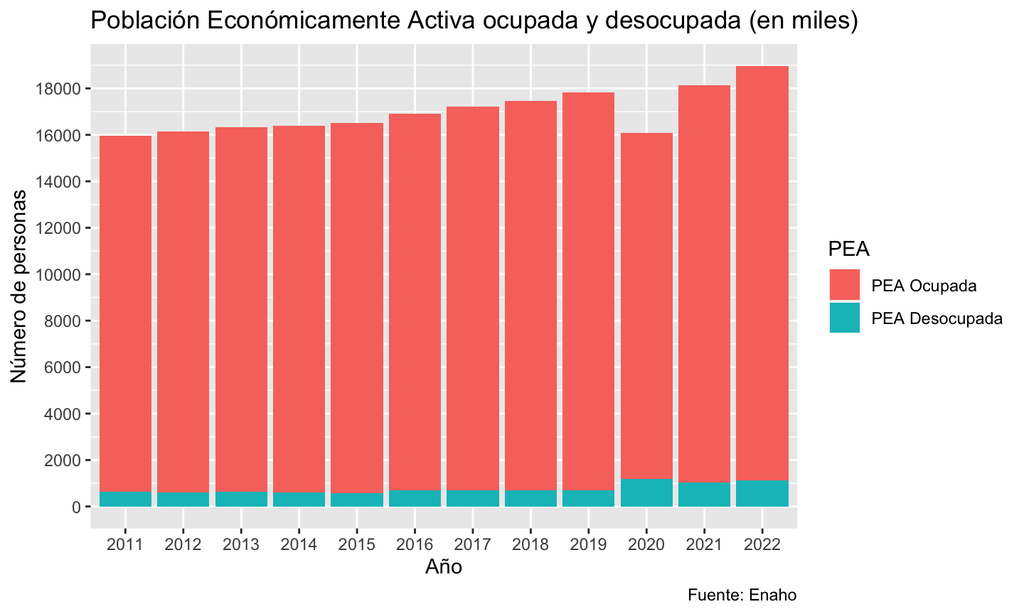

## Tasa de Desempleo

[figure not shown]

## Tasa de informalidad por zona de residencia

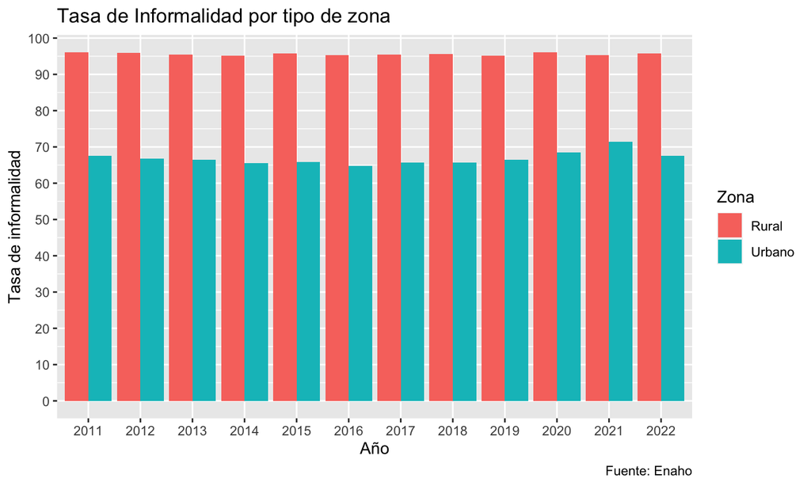

## Tasa de informalidad hombres y mujeres

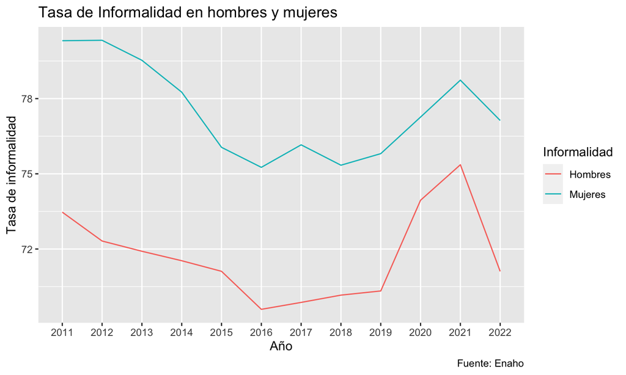

## PEA informal por grupo etario

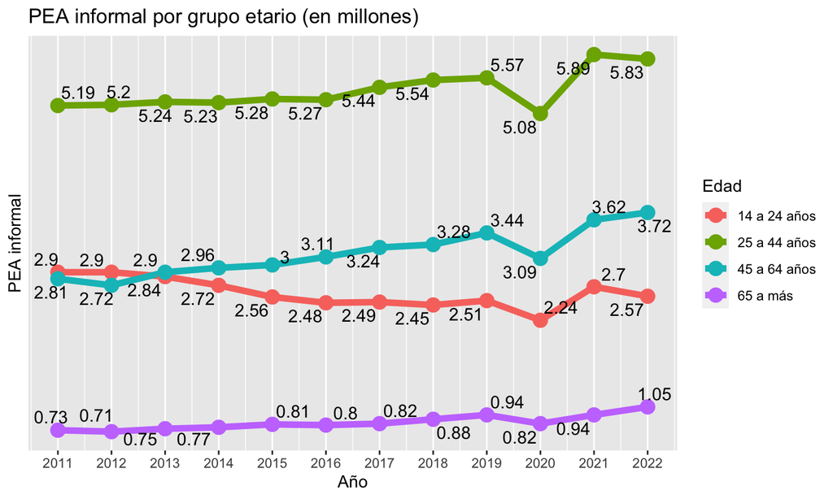

## PEA informal por tamaño de empresa

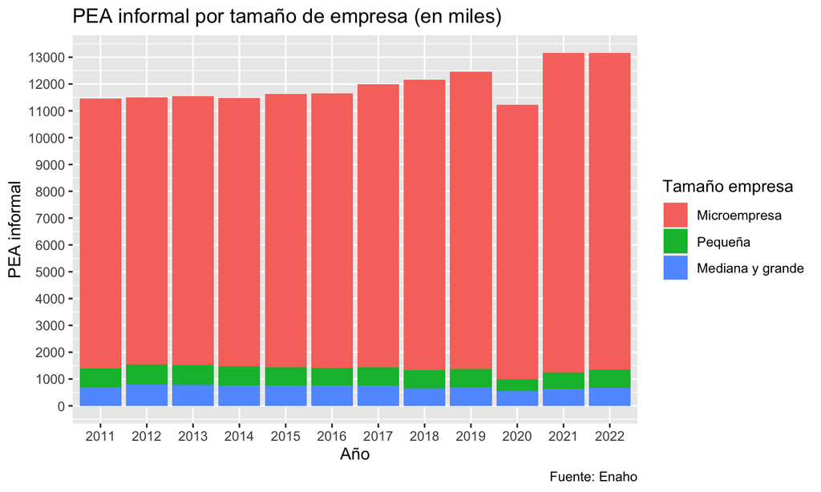

## Ingresos promedio mensuales formales e informales

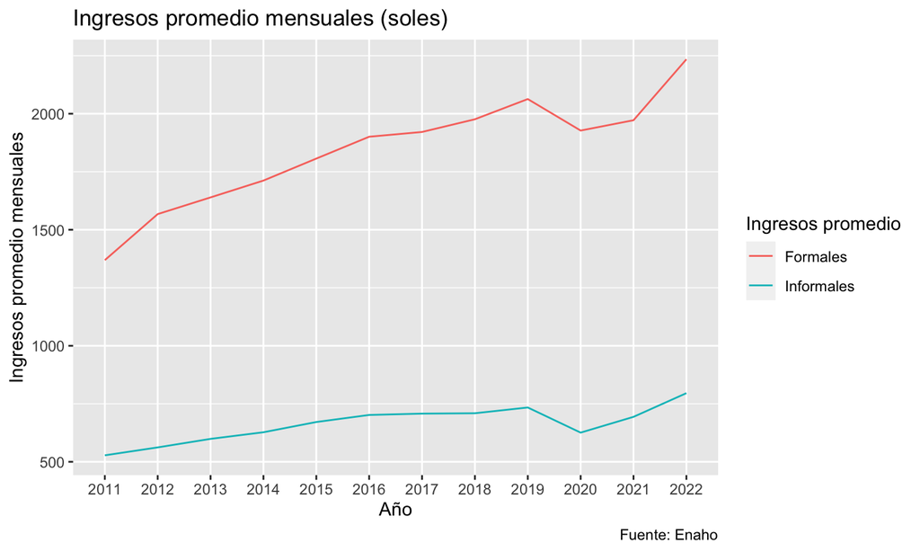

## Variaciones de la tasa de informalidad por departamentos

Variaciones de la tasa de informalidad versus 2019

| Año | Menor incremento | Mayor incremento |
| --- | --- | --- |
| 2020 | Lambayeque: de 75.4% a 72.5% | Pasco: de 78.1% a 87.0% |
| 2021 | La Libertad: de 72.8% a 73.3% | Ica: de 61.4% a 69.1% |

## Departamentos con mayor tasa de informalidad entre 2019 - 2021

Tasa de informalidad 2019 y 2021 por regiones

| Departamento | 2019 | 2021 |
| --- | --- | --- |
| HUANCAVELICA | 92.0 | 94.8 |
| CAJAMARCA | 87.9 | 89.4 |
| PUNO | 87.6 | 90.4 |
| AYACUCHO | 87.3 | 88.8 |
| HUANUCO | 86.6 | 89.7 |
| APURIMAC | 85.4 | 90.5 |

## Tasa de informalidad por departamentos en 2019

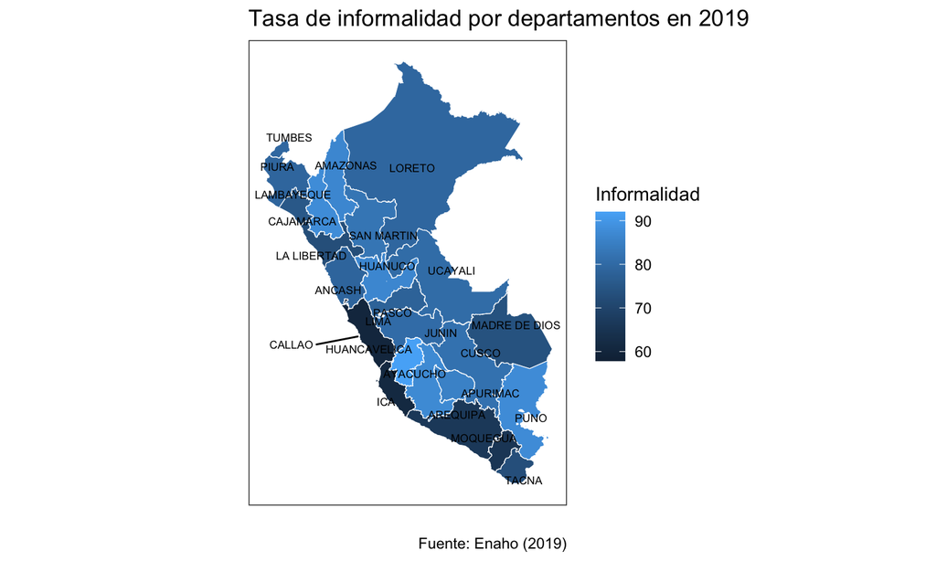

## Tasa de informalidad por departamento en 2021

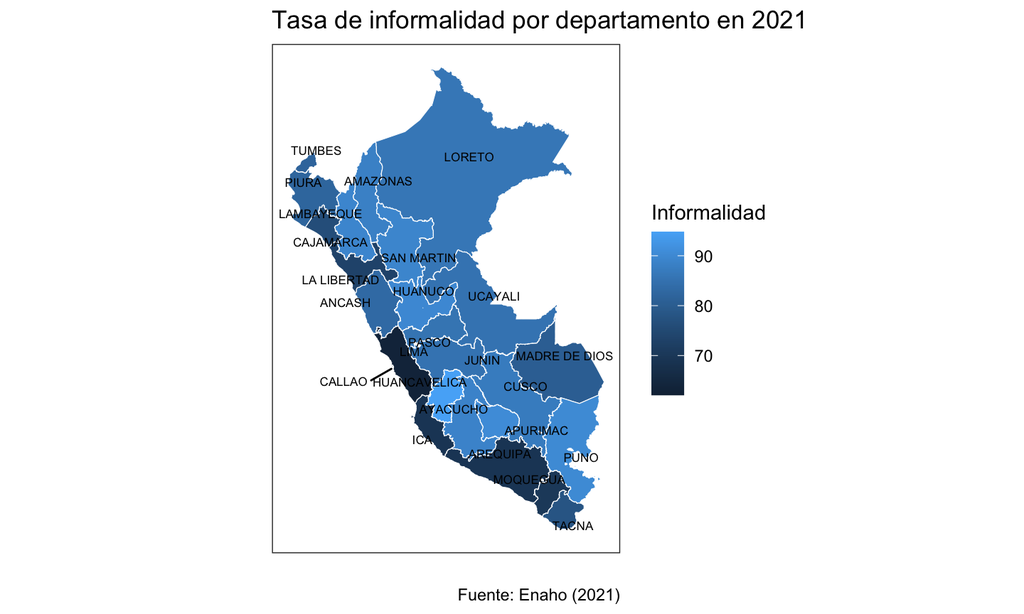

## V. Bibliografía

GEOGPS. (2015). *GEO GPS PERÚ*. https://www.geogpsperu.com/2014/03/base-de-datos-peru-shapefile-shp-minam.html

INEI. (2023). Instituto nacional de estadística e informática. *Lima, Perú*.